# R Bookclub

04/03/2019

## Chapter 2: Workflow basics

## R as a calculator

```r
2+4
```

```
[1] 6
```

```r
pi
```

```
[1] 3.141593
```

```r
(pi+1)/2
```

```
[1] 2.070796
```

## Objects & Naming

Use **‘<-’** to attribute value to objects

```r
floors_harwick <- 8
```

```r
floors_gonda <- 19
```

Exercise:

```r
floor_diff <- floors_gonda - floors_harwick
```

```r
floor_diff
```

```
[1] 11
```

## Functions

Provide input arguments, Obtain output

Example: **seq()**

- Two arguments needed: seq(from, to)
- R produces a **seq**uence of integers from provided arguments

```r
seq(10,20)
```

```
 [1] 10 11 12 13 14 15 16 17 18 19 20
```

Function documentation is found by typing “?” + function name in the Console:

```r
?seq
```

## Exercises

Find the error in my code

```r
ggplot(dota = mpg) +
  geom_point(mapping = aes(x=displ, y=hwy))
```

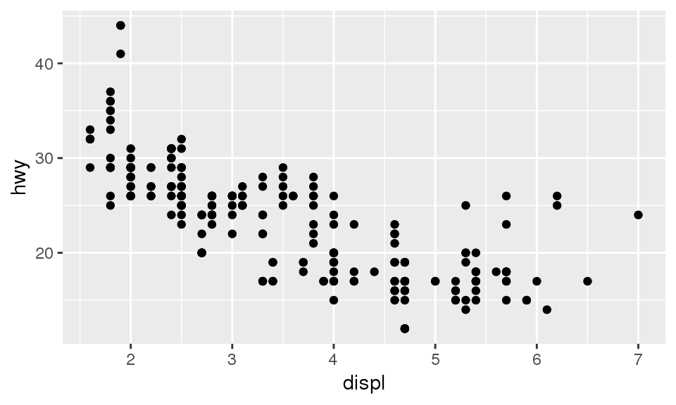

```r
ggplot(data = mpg) +
  geom_point(mapping = aes(x=displ, y=hwy))
```

## Exercises cont.

```r
fliter(mpg, cyl=8)
```

```r
filter(mpg, cyl==8)
```

```
# A tibble: 70 x 11
   manufacturer model displ  year   cyl trans drv     cty   hwy fl    class
   <chr>        <chr> <dbl> <int> <int> <chr> <chr> <int> <int> <chr> <chr>
 1 audi         a6 q…   4.2  2008     8 auto… 4        16    23 p     mids…
 2 chevrolet    c150…   5.3  2008     8 auto… r        14    20 r     suv
 3 chevrolet    c150…   5.3  2008     8 auto… r        11    15 e     suv
 4 chevrolet    c150…   5.3  2008     8 auto… r        14    20 r     suv
 5 chevrolet    c150…   5.7  1999     8 auto… r        13    17 r     suv
 6 chevrolet    c150…   6    2008     8 auto… r        12    17 r     suv
 7 chevrolet    corv…   5.7  1999     8 manu… r        16    26 p     2sea…
 8 chevrolet    corv…   5.7  1999     8 auto… r        15    23 p     2sea…
 9 chevrolet    corv…   6.2  2008     8 manu… r        16    26 p     2sea…
10 chevrolet    corv…   6.2  2008     8 auto… r        15    25 p     2sea…
# ... with 60 more rows
```

## Exercises cont.

```r
filter(diamond, carat>3)
```

```r
filter(diamonds, carat>3)
```

```
# A tibble: 32 x 10
   carat cut     color clarity depth table price     x     y     z
   <dbl> <ord>   <ord> <ord>   <dbl> <dbl> <int> <dbl> <dbl> <dbl>
 1  3.01 Premium I     I1       62.7    58  8040  9.1   8.97  5.67
 2  3.11 Fair    J     I1       65.9    57  9823  9.15  9.02  5.98
 3  3.01 Premium F     I1       62.2    56  9925  9.24  9.13  5.73
 4  3.05 Premium E     I1       60.9    58 10453  9.26  9.25  5.66
 5  3.02 Fair    I     I1       65.2    56 10577  9.11  9.02  5.91
 6  3.01 Fair    H     I1       56.1    62 10761  9.54  9.38  5.31
 7  3.65 Fair    H     I1       67.1    53 11668  9.53  9.48  6.38
 8  3.24 Premium H     I1       62.1    58 12300  9.44  9.4   5.85
 9  3.22 Ideal   I     I1       62.6    55 12545  9.49  9.42  5.92
10  3.5  Ideal   H     I1       62.8    57 12587  9.65  9.59  6.03
# ... with 22 more rows
```

## Keyboard Tips & Shortcuts

- Snake Case (Examples: “floors_harwick” , “cohort_A” , “scatter_MCHS”)

```
  * Descriptive and readable object names
  * Avoid camel case and periods
```

- Use **(Alt) (-)** as a keyboard shortcut for **<-**
- Using “Tab” to explore objects
- RStudio Environment & History: (Cmd) (Ctrl) (-) (up arrow)
- Shortcut Cheatsheet: (Alt) (Shift) (K)

## Chapter 3: Transformations with dplyr

## Variable Types

- *int* (Integers)
- *dbl* (Doubles or real numbers)
- *chr* (Character vectors or strings)
- *dttm* (Date / Times)

## ?dplyr

**What** is it?

```
dplyr is an R package containing functions useful to transform and manipulate data.
```

**Why** dplyr?

```
Intuitive, readable, and fast!
```

Five key dplyr functions:

```
1. filter
2. arrange
3. select
4. mutate
5. summarize
```

## dplyr Function Workflow

Load in the dplyr package

```r
library(dplyr)
```

1. Provide the function a dataframe
2. Describe what to do to the dataframe with column specifications
3. Output to a new dataframe

## The Data

```r
flights
```

```
# A tibble: 336,776 x 19
    year month   day dep_time sched_dep_time dep_delay arr_time
   <int> <int> <int>    <int>          <int>     <dbl>    <int>
 1  2013     1     1      517            515         2      830
 2  2013     1     1      533            529         4      850
 3  2013     1     1      542            540         2      923
 4  2013     1     1      544            545        -1     1004
 5  2013     1     1      554            600        -6      812
 6  2013     1     1      554            558        -4      740
 7  2013     1     1      555            600        -5      913
 8  2013     1     1      557            600        -3      709
 9  2013     1     1      557            600        -3      838
10  2013     1     1      558            600        -2      753
# ... with 336,766 more rows, and 12 more variables: sched_arr_time <int>,
#   arr_delay <dbl>, carrier <chr>, flight <int>, tailnum <chr>,
#   origin <chr>, dest <chr>, air_time <dbl>, distance <dbl>, hour <dbl>,
#   minute <dbl>, time_hour <dttm>
```

## ‘filter’: Subset Rows

## ‘filter’ workflow

- Provide the function a dataframe

```r
filter(flights)
```

- Describe what to do to the dataframe with column specifications

```r
filter(flights, month == 1 , day == 1)
```

- Output to a new dataframe

```r
(flights_1_1 <- filter(flights,  month == 1 , day == 1))
```

```
# A tibble: 842 x 19
    year month   day dep_time sched_dep_time dep_delay arr_time
   <int> <int> <int>    <int>          <int>     <dbl>    <int>
 1  2013     1     1      517            515         2      830
 2  2013     1     1      533            529         4      850
 3  2013     1     1      542            540         2      923
 4  2013     1     1      544            545        -1     1004
 5  2013     1     1      554            600        -6      812
 6  2013     1     1      554            558        -4      740
 7  2013     1     1      555            600        -5      913
 8  2013     1     1      557            600        -3      709
 9  2013     1     1      557            600        -3      838
10  2013     1     1      558            600        -2      753
# ... with 832 more rows, and 12 more variables: sched_arr_time <int>,
#   arr_delay <dbl>, carrier <chr>, flight <int>, tailnum <chr>,
#   origin <chr>, dest <chr>, air_time <dbl>, distance <dbl>, hour <dbl>,
#   minute <dbl>, time_hour <dttm>
```

## Useful Operators

Use operators to specify your “filter” statement.

1. “and” statement: **&**
2. “or” statement: **|**
3. “not” statement: **!=**
4. extended “or” statement: **%in%**

Find all flights operated by United (“UA”), American (“AA”), or Delta (“DL”)

```r
filter(flights, carrier %in% c( "UA", "AA",  "DL" ))
```

## More Exercises

```r
filter(flights, arr_delay >=2)
```

Find flights that flew to “IAH” or “HOU”

```r
filter(flights, dest == "IAH" | dest == "HOU")
filter(flights, dest %in% c("IAH","HOU"))
```

```r
filter(flights, dep_delay >= 1 & arr_delay < -30)
```

## Exercises cont.

The *between( column, min, max)* function is also a useful dplyr verb.

```r
filter( dataframe, between(column, min, max) )
```

How can we use it in this example?

Find flights that departed between July, August, and September.

```r
filter(flights, between(month,7,9))
```

```
# A tibble: 3 x 19
   year month   day dep_time sched_dep_time dep_delay arr_time
  <int> <int> <int>    <int>          <int>     <dbl>    <int>
1  2013     7     1        1           2029       212      236
2  2013     7     1        2           2359         3      344
3  2013     7     1       29           2245       104      151
# ... with 12 more variables: sched_arr_time <int>, arr_delay <dbl>,
#   carrier <chr>, flight <int>, tailnum <chr>, origin <chr>, dest <chr>,
#   air_time <dbl>, distance <dbl>, hour <dbl>, minute <dbl>,
#   time_hour <dttm>
```

## Exercises cont.

Which flights are missing a “dep_time”?

```r
filter(flights, is.na(dep_time))
```

```
# A tibble: 3 x 19
   year month   day dep_time sched_dep_time dep_delay arr_time
  <int> <int> <int>    <int>          <int>     <dbl>    <int>
1  2013     1     1       NA           1630        NA       NA
2  2013     1     1       NA           1935        NA       NA
3  2013     1     1       NA           1500        NA       NA
# ... with 12 more variables: sched_arr_time <int>, arr_delay <dbl>,
#   carrier <chr>, flight <int>, tailnum <chr>, origin <chr>, dest <chr>,
#   air_time <dbl>, distance <dbl>, hour <dbl>, minute <dbl>,
#   time_hour <dttm>
```

What could these rows represent?

## ‘arrange’: Order your Data

## ‘arrange’

Order dataset by provided columns in ascending order

```r
(flight_month <- arrange(flights, month))
```

```
# A tibble: 336,776 x 19
    year month   day dep_time sched_dep_time dep_delay arr_time
   <int> <int> <int>    <int>          <int>     <dbl>    <int>
 1  2013     1     1      517            515         2      830
 2  2013     1     1      533            529         4      850
 3  2013     1     1      542            540         2      923
 4  2013     1     1      544            545        -1     1004
 5  2013     1     1      554            600        -6      812
 6  2013     1     1      554            558        -4      740
 7  2013     1     1      555            600        -5      913
 8  2013     1     1      557            600        -3      709
 9  2013     1     1      557            600        -3      838
10  2013     1     1      558            600        -2      753
# ... with 336,766 more rows, and 12 more variables: sched_arr_time <int>,
#   arr_delay <dbl>, carrier <chr>, flight <int>, tailnum <chr>,
#   origin <chr>, dest <chr>, air_time <dbl>, distance <dbl>, hour <dbl>,
#   minute <dbl>, time_hour <dttm>
```

Default: ascending order

## ‘arrange’ cont.

Arranging the data in the opposite direction (descending order):

```r
(flight_year_month <- arrange(flights, desc(month)))
```

```
# A tibble: 336,776 x 19
    year month   day dep_time sched_dep_time dep_delay arr_time
   <int> <int> <int>    <int>          <int>     <dbl>    <int>
 1  2013    12     1       13           2359        14      446
 2  2013    12     1       17           2359        18      443
 3  2013    12     1      453            500        -7      636
 4  2013    12     1      520            515         5      749
 5  2013    12     1      536            540        -4      845
 6  2013    12     1      540            550       -10     1005
 7  2013    12     1      541            545        -4      734
 8  2013    12     1      546            545         1      826
 9  2013    12     1      549            600       -11      648
10  2013    12     1      550            600       -10      825
# ... with 336,766 more rows, and 12 more variables: sched_arr_time <int>,
#   arr_delay <dbl>, carrier <chr>, flight <int>, tailnum <chr>,
#   origin <chr>, dest <chr>, air_time <dbl>, distance <dbl>, hour <dbl>,
#   minute <dbl>, time_hour <dttm>
```

## ‘arrange’: cont.

Multiple arguments in the arrange statement.

```r
flight_year_dep <- arrange(flights, year, dep_time)
```

```
# A tibble: 4 x 19
   year month   day dep_time sched_dep_time dep_delay arr_time
  <int> <int> <int>    <int>          <int>     <dbl>    <int>
1  2013     1    13        1           2249        72      108
2  2013     1    31        1           2100       181      124
3  2013    11    13        1           2359         2      442
4  2013    12    16        1           2359         2      447
# ... with 12 more variables: sched_arr_time <int>, arr_delay <dbl>,
#   carrier <chr>, flight <int>, tailnum <chr>, origin <chr>, dest <chr>,
#   air_time <dbl>, distance <dbl>, hour <dbl>, minute <dbl>,
#   time_hour <dttm>
```

*What happens to NA values in arrange() statements?*

## Handling NAs and Missing Values

> To determine if a value is missing/NA, use the ‘is.na()’ function:

```r
x <- NA
is.na(x)
```

```
[1] TRUE
```

> The following result in NA:

```r
NA > 5
10 == NA
NA + 10
NA / 2
```

> *Rule-* if the calculation involves NA, result will almost always be NA.

## NAs: Exceptions

```r
NA ^ 0
```

```
[1] 1
```

```r
NA | TRUE
```

```
[1] TRUE
```

## Exercises

How can we sort missing values to the top of the dataset?

```r
arrange(flights, desc(is.na(dep_time)))
```

Find flights that were most delayed, then sort by those that left earliest

```r
arrange(flights, desc(dep_delayed), departure)
```

Find the longest flights

```r
arrange(flights, desc(air_time))
```

## ‘select’: Select Columns of Data

## ‘select’

```r
flights_ymd <- select(flights, year, month, day)
flights_ymd
```

```
# A tibble: 336,776 x 3
    year month   day
   <int> <int> <int>
 1  2013     1     1
 2  2013     1     1
 3  2013     1     1
 4  2013     1     1
 5  2013     1     1
 6  2013     1     1
 7  2013     1     1
 8  2013     1     1
 9  2013     1     1
10  2013     1     1
# ... with 336,766 more rows
```

## ‘select’ cont.

Selecting all columns between ‘carrier’ and ‘origin’

```r
select(flights, carrier:origin)
```

```
# A tibble: 336,776 x 4
   carrier flight tailnum origin
   <chr>    <int> <chr>   <chr>
 1 UA        1545 N14228  EWR
 2 UA        1714 N24211  LGA
 3 AA        1141 N619AA  JFK
 4 B6         725 N804JB  JFK
 5 DL         461 N668DN  LGA
 6 UA        1696 N39463  EWR
 7 B6         507 N516JB  EWR
 8 EV        5708 N829AS  LGA
 9 B6          79 N593JB  JFK
10 AA         301 N3ALAA  LGA
# ... with 336,766 more rows
```

## ‘select’ cont.

Selecting all columns except those from ‘carrier’ to ‘origin’

```r
select(flights, -(carrier : origin))
```

```
# A tibble: 336,776 x 15
    year month   day dep_time sched_dep_time dep_delay arr_time
   <int> <int> <int>    <int>          <int>     <dbl>    <int>
 1  2013     1     1      517            515         2      830
 2  2013     1     1      533            529         4      850
 3  2013     1     1      542            540         2      923
 4  2013     1     1      544            545        -1     1004
 5  2013     1     1      554            600        -6      812
 6  2013     1     1      554            558        -4      740
 7  2013     1     1      555            600        -5      913
 8  2013     1     1      557            600        -3      709
 9  2013     1     1      557            600        -3      838
10  2013     1     1      558            600        -2      753
# ... with 336,766 more rows, and 8 more variables: sched_arr_time <int>,
#   arr_delay <dbl>, dest <chr>, air_time <dbl>, distance <dbl>,
#   hour <dbl>, minute <dbl>, time_hour <dttm>
```

## ‘select’ helper statements

> starts_with(“x”)

```
selects columns that begin with "x"
```

> ends_with(“type”)

```
selects columns that end with "type"
```

> contains(“gene”)

```
selects columns that contain "gene"
```

> num_range(“x”, 1:3)

```
selects columns titled, "x1", "x2", and "x3"
```

## Exercises

What happens if you refer to the same column multiple times in a ‘select’ call?

```r
select(flights, year, year)
```

```
# A tibble: 3 x 1
   year
  <int>
1  2013
2  2013
3  2013
```

## Exercises cont.

What does the ‘one_of’ function do? How could it be useful in a select statement?

Given a vector of characters, ‘one_of’ finds column names that match in the vector.

```r
variables <- c("year", "month", "day","arr_time")
```

```r
select(flights, one_of(variables))
```

```
# A tibble: 3 x 4
   year month   day arr_time
  <int> <int> <int>    <int>
1  2013     1     1      830
2  2013     1     1      850
3  2013     1     1      923
```

## Column Manipulation

Use ‘rename’ to change column names

Syntax: rename(data, *new_column_name* = old_column_name)

```r
rename(flights, depart_delay = dep_delay)
```

```
# A tibble: 336,776 x 19
    year month   day dep_time sched_dep_time depart_delay arr_time
   <int> <int> <int>    <int>          <int>        <dbl>    <int>
 1  2013     1     1      517            515            2      830
 2  2013     1     1      533            529            4      850
 3  2013     1     1      542            540            2      923
 4  2013     1     1      544            545           -1     1004
 5  2013     1     1      554            600           -6      812
 6  2013     1     1      554            558           -4      740
 7  2013     1     1      555            600           -5      913
 8  2013     1     1      557            600           -3      709
 9  2013     1     1      557            600           -3      838
10  2013     1     1      558            600           -2      753
# ... with 336,766 more rows, and 12 more variables: sched_arr_time <int>,
#   arr_delay <dbl>, carrier <chr>, flight <int>, tailnum <chr>,
#   origin <chr>, dest <chr>, air_time <dbl>, distance <dbl>, hour <dbl>,
#   minute <dbl>, time_hour <dttm>
```

## Column Manipulation cont.

Use ‘select’ and ‘everything’ together to rearrange columns

```r
select(flights, time_hour, air_time, everything())
```

```
# A tibble: 336,776 x 19
   time_hour           air_time  year month   day dep_time sched_dep_time
   <dttm>                 <dbl> <int> <int> <int>    <int>          <int>
 1 2013-01-01 05:00:00      227  2013     1     1      517            515
 2 2013-01-01 05:00:00      227  2013     1     1      533            529
 3 2013-01-01 05:00:00      160  2013     1     1      542            540
 4 2013-01-01 05:00:00      183  2013     1     1      544            545
 5 2013-01-01 06:00:00      116  2013     1     1      554            600
 6 2013-01-01 05:00:00      150  2013     1     1      554            558
 7 2013-01-01 06:00:00      158  2013     1     1      555            600
 8 2013-01-01 06:00:00       53  2013     1     1      557            600
 9 2013-01-01 06:00:00      140  2013     1     1      557            600
10 2013-01-01 06:00:00      138  2013     1     1      558            600
# ... with 336,766 more rows, and 12 more variables: dep_delay <dbl>,
#   arr_time <int>, sched_arr_time <int>, arr_delay <dbl>, carrier <chr>,
#   flight <int>, tailnum <chr>, origin <chr>, dest <chr>, distance <dbl>,
#   hour <dbl>, minute <dbl>
```

## mutate: Create Columns

## ‘mutate’

Create and append columns to exisiting data with ‘mutate’

Syntax:

mutate(data, *new_column_name* = column manipulation )

## ‘mutate’ example

```r
flights_A <- select(flights, year : day, arr_delay, starts_with("dep"))
```

```
# A tibble: 3 x 6
   year month   day arr_delay dep_time dep_delay
  <int> <int> <int>     <dbl>    <int>     <dbl>
1  2013     1     1        11      517         2
2  2013     1     1        20      533         4
3  2013     1     1        33      542         2
```

```r
mutate(flights_A,
       gain = arr_delay - dep_delay)
```

```
# A tibble: 3 x 7
   year month   day arr_delay dep_time dep_delay  gain
  <int> <int> <int>     <dbl>    <int>     <dbl> <dbl>
1  2013     1     1        11      517         2     9
2  2013     1     1        20      533         4    16
3  2013     1     1        33      542         2    31
```

## ‘mutate’ Multiple Columns

```r
mutate(flights_A,
       gain = arr_delay - dep_delay,
       arr_dep_diff = arr_delay - dep_time)
```

```
# A tibble: 5 x 8
   year month   day arr_delay dep_time dep_delay  gain arr_dep_diff
  <int> <int> <int>     <dbl>    <int>     <dbl> <dbl>        <dbl>
1  2013     1     1        11      517         2     9         -506
2  2013     1     1        20      533         4    16         -513
3  2013     1     1        33      542         2    31         -509
4  2013     1     1       -18      544        -1   -17         -562
5  2013     1     1       -25      554        -6   -19         -579
```

## ‘transmute’

‘transmute’ is the same as ‘mutate’, but will instead only keep the new variables:

```r
transmute(flights_A,
       gain = arr_delay - dep_delay,
       arr_dep_diff = arr_delay - dep_time)
```

```
# A tibble: 336,776 x 2
    gain arr_dep_diff
   <dbl>        <dbl>
 1     9         -506
 2    16         -513
 3    31         -509
 4   -17         -562
 5   -19         -579
 6    16         -542
 7    24         -536
 8   -11         -571
 9    -5         -565
10    10         -550
# ... with 336,766 more rows
```

## Useful Functions When Mutating

> / , + , -, * , ^

> sum(), mean()

> %/% (integer division)

```r
4 %/% 2
```

```
[1] 2
```

> %% (remainder)

```r
4 %% 2
```

```
[1] 0
```

## Useful Functions When Mutating cont.

Logs

- Natural logarithms

```r
log()
```

- Binary logarithms (base 2)

```r
log2()
```

- Common logarithms (base 10)

```r
log10()
```

## Useful Functions cont : Offsets

‘lead’ & ‘lag’

```r
(tn <- 1:10)
```

```
 [1]  1  2  3  4  5  6  7  8  9 10
```

```r
(lead(tn))
```

```
 [1]  2  3  4  5  6  7  8  9 10 NA
```

```r
(lag(tn))
```

```
 [1] NA  1  2  3  4  5  6  7  8  9
```

## Useful Functions cont : Aggregates

Cumulative and rolling calculations

What is the sum of all previous values (including current value)?

```r
cumsum(tn)
```

```
 [1]  1  3  6 10 15 21 28 36 45 55
```

What is the mean of all previous values (including current value)?

```r
cummean(tn)
```

```
 [1] 1.0 1.5 2.0 2.5 3.0 3.5 4.0 4.5 5.0 5.5
```

others: ‘cummin’ , ‘cummax’, ‘cumprod’

## Useful Functions cont : Comparisons

Logical comparisons

```r
<
>
<=
>=
!=
==
```

## Exercises

**Note:** ‘min_rank’ assigns a number equal to a number of elements less than that value plus one.

```r
mr <- c(4, 2, 7, 7, 7 , 0, 10)
min_rank(mr)
```

```
[1] 3 2 4 4 4 1 7
```

```r
min_rank(desc(mr))
```

```
[1] 5 6 2 2 2 7 1
```

## Exercises cont.

```r
flights_delay <- mutate(flights, delay_rank = min_rank(desc(dep_delay)))
```

```r
flights_delay <- select(flights_delay, delay_rank, dep_delay, everything())
```

```r
arrange(flights_delay, delay_rank)[1:5,]
```

```
# A tibble: 5 x 20
  delay_rank dep_delay  year month   day dep_time sched_dep_time arr_time
       <int>     <dbl> <int> <int> <int>    <int>          <int>    <int>
1          1      1301  2013     1     9      641            900     1242
2          2      1137  2013     6    15     1432           1935     1607
3          3      1126  2013     1    10     1121           1635     1239
4          4      1014  2013     9    20     1139           1845     1457
5          5      1005  2013     7    22      845           1600     1044
# ... with 12 more variables: sched_arr_time <int>, arr_delay <dbl>,
#   carrier <chr>, flight <int>, tailnum <chr>, origin <chr>, dest <chr>,
#   air_time <dbl>, distance <dbl>, hour <dbl>, minute <dbl>,
#   time_hour <dttm>
```

## Exercises cont.

## ‘summarize’: Aggregate Calculations

## ‘summarize’

Collapses data into a single row:

```r
summarize(flights, avg_delay = mean(dep_delay, na.rm = TRUE))
```

```
# A tibble: 1 x 1
  avg_delay
      <dbl>
1      12.6
```

‘summarize’ is not too useful on its own.  
It is often used in tandem with

**Pipes and ‘group_by’**

## Pipes and ‘group_by’

## Grouped Summaries with “group_by”

Implement *group_by* to use dplyr functions on a *grouped* dataframe

Example:

```r
by_day <- group_by(flights, year, month, day)
```

The above code does nothing to the structure of the data. The data is merely coerced into a grouped dataframe.

```r
summarize(by_day, delay = mean(dep_delay, na.rm = TRUE))[1:3,]
```

```
# A tibble: 3 x 4
# Groups:   year, month [1]
   year month   day delay
  <int> <int> <int> <dbl>
1  2013     1     1  11.5
2  2013     1     2  13.9
3  2013     1     3  11.0
```

## A note on ‘na.rm’

Recall, *most* calculations that include ‘NA’ values will result in an ‘NA’.

```r
mean(c(2,3,4,NA, 6))
```

```
[1] NA
```

Omit the ‘NA’ values in the calculation with use the option *na.rm=TRUE*

```r
mean(c(2,3,4,NA,6), na.rm = TRUE)
```

```
[1] 3.75
```

## Ungrouping

Data can be ungrouped at any time

```r
by_day <- group_by(flights, year, month, day)
```

```r
orig_data <- ungroup(by_day)
```

## Piping with ‘%>%’

Pipes allow multiple ‘dplyr’ functions to be used consecutively.

For example, you may want to take your original data, and then:

1. Select specific columns
2. Filter for observations
3. Create (mutate) another column

Data **%>%** Select columns **%>%** Filter observations **%>%** Create a column

## Pipe Framework

```r
flight_a <- flights %>% select(year, air_time, dest) %>% mutate(air_time_hours = air_time/60)
```

1. Provide a dataset
2. Pipe ( %>% )
3. Input desired ‘dplyr’ function
4. Repeat steps 2 - 3 as needed
5. Output into a new object

```
# A tibble: 3 x 4
   year air_time dest  air_time_hours
  <int>    <dbl> <chr>          <dbl>
1  2013      227 IAH             3.78
2  2013      227 IAH             3.78
3  2013      160 MIA             2.67
```

## Pipes and ‘group_by’ together

> Using both pipes and ‘group_by’ allows data manipulation to groups of data.

> Consider the question: What was the average departure delay in each month?

> ‘group_by’ month, use the ‘summarize’ function

```r
flights %>% group_by(month) %>% summarize(avg_delay = mean(dep_delay,na.rm=TRUE))
```

```
# A tibble: 4 x 2
  month avg_delay
  <int>     <dbl>
1     1      10.0
2     2      10.8
3     3      13.2
4     4      13.9
```

## Useful Summary Functions

```r
flights %>% group_by(month) %>% summarize()
```

> **Location:** mean(x), median(x)

> **Spread:** sd(x), IQR(x), mad(x) *(median absolute deviation)*

> **Rank:** min(x), quantile( x, 0.5) , max(x)

> **Position:** first(x) , nth(x, 5), last(x)

> **Counts:** n(), sum(is.na(x)), sum(!(is.na(x))), n_distinct(x)

Find the sum of ‘NAs’ in the origin column in each month:

```r
flights %>% group_by(month) %>% summarize(na_origin = sum(is.na(origin)))
```

## Exercises

Provide another approach to attain output from the following:

```r
not_cancelled %>% count(dest)
```

Essentially: Find all flights that are not cancelled.

One solution:

```r
not_cancelled <- flights %>%
  filter(!is.na(dep_delay), !is.na(arr_delay))
```

Other solutions?

If a flight never departs, then it won’t arrive. But a flight could also depart and not arrive (crashes, lost flights). We could use ‘arr_delay’ as a proxy to define cancelled flights.

## Exercises cont.

For each plane, count the number of flights before the first delay of greater than one hour.

What dplyr verbs do we want to use?

```r
flights %>%
  arrange(tailnum, year, month, day) %>%
  group_by(tailnum) %>%
  mutate(delay_gt1hr = dep_delay > 60) %>%
  mutate(before_delay = cumsum(delay_gt1hr)) %>%
  filter(before_delay < 1) %>%
  count(sort = TRUE)
```

## Exercises

For each destination, compute the total minutes of delay.

For each flight, compute the proportion of the total delay for its destination.

```r
flights %>%
  filter(!is.na(arr_delay), arr_delay > 0) %>%
  group_by(dest) %>%
  mutate(
    arr_delay_total = sum(arr_delay),
    arr_delay_prop = arr_delay / arr_delay_total) %>%
  ungroup()
```

## Exercises cont.

Find destinations that are flown by at least two carriers.

```r
dest_2carriers <- flights %>%
  # keep only unique carrier,dest pairs
  select(dest, carrier) %>%
  group_by(dest, carrier) %>%
  filter(row_number() == 1) %>%
  # count carriers by destination
  group_by(dest) %>%
  mutate(n_carrier = n_distinct(carrier)) %>%
  filter(n_carrier >= 2)
```